# diffloop: Identifying differential DNA loops from ChIA-PET data

Caleb Lareau & Martin Aryee

2016-05-23

## Preprocessing

The raw FASTQ read files were preprocessed with the `dnaloop` (https://github.com/aryeelab/dnaloop) package, a `PyPi` package that relies on `samtools`, `bedtools`, `cutadapt`, and `MACS2` to align reads, call anchor peaks, and summarize PETs per sample in the ChIA-PET experiment.  
To use the `loopsMake` function from a different preprocessing step, have files `X.loop_counts.bedpe`,`Y.loop_counts.bedpe`, `Z.loop_counts.bedpe` in `bed_dir` for `samples = (X,Y,Z)` where the first lines should resemble:  
1 10002272 10004045 10 120968807 120969483 . 1  
1 10002272 10004045 10 99551498 99552470 . 1  
1 10002272 10004045 1 10002272 10004045 . 17  
where the first three columns specify the position (chr:start:stop) of the first anchor, the second three columns specify the position (chr:start:stop) of the secnd anchor, the 7th column is “.” and the 8th column is the number of paired-end reads support that particular PET.

## Loading data

We read in data from the preprocessing pipeline using the `loopsMake` function. The example below uses sample data included in the `diffloopdata` package. It contains interactions involving chromosome 1 from a set of six Cohesin ChIA-PET samples.$^{1,2}$ You would normally set `bed_dir` to your real data directory.

```r
bed_dir <- system.file("extdata", "esc_jurkat", package="diffloopdata")
bed_dir
```

```
## [1] "/Library/Frameworks/R.framework/Versions/3.3/Resources/library/diffloopdata/extdata/esc_jurkat"
```

```r
samples <- c("naive_esc_1", "naive_esc_2", "primed_esc_1", "primed_esc_2",
            "jurkat_1", "jurkat_2")
```

Here, we use 1500 bp as a value to merge nearby anchors into a single peak. In the `loopsMake` function, the default is zero and should be parameterized based on the resolution of the ChIA-PET Experiment.

```r
full <- loopsMake(bed_dir, samples, 1500)
celltypes <- c("naive", "naive", "primed", "primed", "jurkat", "jurkat")
full <- updateLDGroups(full, celltypes)
head(full, 3)
```

```
## An object of class "loops"
## Slot "anchors":
## GRanges object with 3 ranges and 0 metadata columns:
##       seqnames           ranges strand
##          <Rle>        <IRanges>  <Rle>
##   [1]        1 [713970, 714336]      *
##   [2]        1 [804939, 805810]      *
##   [3]        1 [839766, 841153]      *
##   -------
##   seqinfo: 51 sequences from an unspecified genome; no seqlengths
##
## Slot "interactions":
##      left right
## [1,]    1     1
## [2,]    1     2
## [3,]    1     3
##
## Slot "counts":
##      naive_esc_1 naive_esc_2 primed_esc_1 primed_esc_2 jurkat_1 jurkat_2
## [1,]           2           2            8            9        2        6
## [2,]           0           1            1            0        0        0
## [3,]           0           1            0            0        0        0
##
## Slot "colData":
##              sizeFactor groups
## naive_esc_1           1  naive
## naive_esc_2           1  naive
## primed_esc_1          1 primed
##
## Slot "rowData":
##   loopWidth
## 1         0
## 2     90604
## 3    125431
```

Alternatively, one could run `full <- loopsMake(bed_dir)` and the `samples` would be inferred from the directory contents. The default call to `loopsMake` does not merge nearby anchors but instead keeps them distinct. If we want to group nearby anchors after the initial data read, one can run the `mergeAnchors` command with the appropriate gap value.  
We’ll now look at a PCA plot of the raw data:

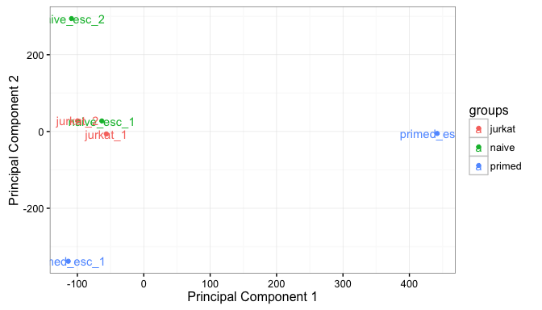

```r
pcaPlot(full) + geom_text(aes(label=samples))
```

From this initial PCA plot, it’s not clear how the samples separate based on their topologies, suggesting some quality control may be warranted.

## QC

First, we normalize the `loops` object, which updates the `sizeFactor` of each sample by the number of reads identical to the normalization technique employed in `DESeq2`. We recommend computing the size factors on the original `loops` object to generate the best normalization factors.

```r
full <- calcLDSizeFactors(full)
head(full,3)
```

```
## An object of class "loops"
## Slot "anchors":
## GRanges object with 3 ranges and 0 metadata columns:
##       seqnames           ranges strand
##          <Rle>        <IRanges>  <Rle>
##   [1]        1 [713970, 714336]      *
##   [2]        1 [804939, 805810]      *
##   [3]        1 [839766, 841153]      *
##   -------
##   seqinfo: 51 sequences from an unspecified genome; no seqlengths
##
## Slot "interactions":
##      left right
## [1,]    1     1
## [2,]    1     2
## [3,]    1     3
##
## Slot "counts":
##      naive_esc_1 naive_esc_2 primed_esc_1 primed_esc_2 jurkat_1 jurkat_2
## [1,]           2           2            8            9        2        6
## [2,]           0           1            1            0        0        0
## [3,]           0           1            0            0        0        0
##
## Slot "colData":
##              sizeFactor groups
## naive_esc_1   0.9164864  naive
## naive_esc_2   1.3742819  naive
## primed_esc_1  0.8946324 primed
##
## Slot "rowData":
##   loopWidth
## 1         0
## 2     90604
## 3    125431
```

```r
loopMetrics(full)
```

```
##        naive_esc_1 naive_esc_2 primed_esc_1 primed_esc_2 jurkat_1 jurkat_2
## self        131766      195502       120366       189452    89371   192755
## unique      139058      196861       202804       249808    78828   167673
```

We define “valid” looping in a combined experiment as those supported by at least 3 replicates in 2 or more samples. We can generate valid loops by using the `filterLoops` command

```r
full_5kb <- filterLoops(full, width=5000, nreplicates=3, nsamples = 1)
dim(full_5kb)
```

```
##   anchors interactions samples colData rowData
## 1    3321         3457       6       2       1
```

```r
valid_full <- filterLoops(full, width=5000, nreplicates=3, nsamples = 2)
dim(valid_full)
```

```
##   anchors interactions samples colData rowData
## 1    1508         1223       6       2       1
```

We can also see the proportion of loops that occur within the same chromosome (intrachromosomal) or have loops that bridge chromosomes (interchromosomal).

```r
dim(intrachromosomal(valid_full))
```

```
##   anchors interactions samples colData rowData
## 1    1506         1221       6       2       1
```

```r
dim(interchromosomal(valid_full))
```

```
##   anchors interactions samples colData rowData
## 1       3            2       6       2       1
```

Finally, we can determine the number of anchors supported by each sample as well as the loops with different thresholds of counts.

```r
numLoops(valid_full,1:5)
```

```
##   nloops naive_esc_1 naive_esc_2 primed_esc_1 primed_esc_2 jurkat_1
## 1      1         641         948          813         1043      422
## 2      2         443         777          605          919      260
## 3      3         249         519          380          641      138
## 4      4         145         353          239          470       79
## 5      5          89         261          175          335       53
##   jurkat_2
## 1      782
## 2      663
## 3      479
## 4      377
## 5      294
```

```r
numAnchors(valid_full)
```

```
##   naive_esc_1 naive_esc_2 primed_esc_1 primed_esc_2 jurkat_1 jurkat_2
## 1         546         222          332          143      896      423
```

## Post-Normalization

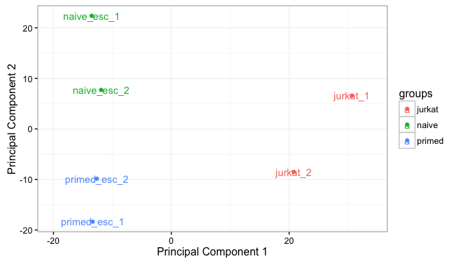

```r
pcaPlot(valid_full) + geom_text(aes(label=samples)) +
    expand_limits(x = c(-20, 34))
```

Here, the PC plot is much better as the first principal component separates the stem cells and the jurkat samples while the second PC separates the two stem cell samples.

## Differential Looping

Here, we describe the most general association method first fitting the model then doing pairwise comparisons by our choice of parameterizing the loopTest function.

```r
# Fit edgeR Models Pairwise between cell types
fit <- loopFit(valid_full)
```

```
## The coefficients of the fitted GLM object are:
## (Intercept) groupsnaive groupsprimed
```

```r
jn_res <- loopTest(fit,coef=2)
jp_res <- loopTest(fit,coef=3)
np_res <- loopTest(fit,contrast=c(0,-1,1))

head(np_res)
```

```
## An object of class "loops"
## Slot "anchors":
## GRanges object with 6 ranges and 0 metadata columns:
##       seqnames             ranges strand
##          <Rle>          <IRanges>  <Rle>
##   [1]        1 [ 919114,  920102]      *
##   [2]        1 [ 967614,  969793]      *
##   [3]        1 [ 999024,  999947]      *
##   [4]        1 [1283357, 1285466]      *
##   [5]        1 [1306905, 1308004]      *
##   [6]        1 [1875093, 1876136]      *
##   -------
##   seqinfo: 51 sequences from an unspecified genome; no seqlengths
##
## Slot "interactions":
##      left right
## [1,]    1     3
## [2,]    2     3
## [3,]    4     5
## [4,]    6     8
## [5,]    7     8
## [6,]    9    10
##
## Slot "counts":
##      naive_esc_1 naive_esc_2 primed_esc_1 primed_esc_2 jurkat_1 jurkat_2
## [1,]           0           1            1            3        4        5
## [2,]           0           2            3            2        1        3
## [3,]           4           3            0            3        1        1
## [4,]           1           3            3            3        0        4
## [5,]          16          14            4            7        3        6
## [6,]           3           4            3           14        3       13
##
## Slot "colData":
##              sizeFactor groups
## naive_esc_1   0.9164864  naive
## naive_esc_2   1.3742819  naive
## primed_esc_1  0.8946324 primed
## primed_esc_2  1.3785983 primed
## jurkat_1      0.5986950 jurkat
## jurkat_2      1.1775918 jurkat
##
## Slot "rowData":
##   loopWidth      logFC    logCPM          F     PValue       FDR
## 1     78923  1.5034418 10.006988 0.88077819 0.34805040 0.9954041
## 2     29232  1.1429494  9.761472 0.63950056 0.42394348 0.9954041
## 3     21440 -1.7024321  9.848206 1.86102123 0.17259065 0.9621587
## 4     99664  0.3855677  9.905277 0.09636986 0.75624786 0.9954041
## 5     83277 -1.9454867 11.353272 5.47819890 0.01930839 0.7332413
## 6    185283  0.8019239 10.918370 0.80410224 0.36992852 0.9954041
```

We could also have computed pairwise associations by subsetting the data and using quickAssoc, which only allows loops objects with two group classes.

```r
np <- valid_full[,1:4]
summary(np[1:3,])
```

```
##   chr_1 start_1   end_1 chr_2 start_2   end_2 naive_esc_1 naive_esc_2
## 1     1  919114  920102     1  999024  999947           0           1
## 2     1  967614  969793     1  999024  999947           0           2
## 3     1 1283357 1285466     1 1306905 1308004           4           3
##   primed_esc_1 primed_esc_2 loopWidth
## 1            1            3     78923
## 2            3            2     29232
## 3            0            3     21440
```

```r
np_res2 <- quickAssoc(np)
```

Instead of determining the loops that distinguish these conditions from each other pairwise, this framework allows us to determine the loops that are significantly different between all of these conditions:

```r
jnp_res <- loopTest(fit,coef=2:3)
head(jnp_res)
```

```
## An object of class "loops"
## Slot "anchors":
## GRanges object with 6 ranges and 0 metadata columns:
##       seqnames             ranges strand
##          <Rle>          <IRanges>  <Rle>
##   [1]        1 [ 919114,  920102]      *
##   [2]        1 [ 967614,  969793]      *
##   [3]        1 [ 999024,  999947]      *
##   [4]        1 [1283357, 1285466]      *
##   [5]        1 [1306905, 1308004]      *
##   [6]        1 [1875093, 1876136]      *
##   -------
##   seqinfo: 51 sequences from an unspecified genome; no seqlengths
##
## Slot "interactions":
##      left right
## [1,]    1     3
## [2,]    2     3
## [3,]    4     5
## [4,]    6     8
## [5,]    7     8
## [6,]    9    10
##
## Slot "counts":
##      naive_esc_1 naive_esc_2 primed_esc_1 primed_esc_2 jurkat_1 jurkat_2
## [1,]           0           1            1            3        4        5
## [2,]           0           2            3            2        1        3
## [3,]           4           3            0            3        1        1
## [4,]           1           3            3            3        0        4
## [5,]          16          14            4            7        3        6
## [6,]           3           4            3           14        3       13
##
## Slot "colData":
##              sizeFactor groups
## naive_esc_1   0.9164864  naive
## naive_esc_2   1.3742819  naive
## primed_esc_1  0.8946324 primed
## primed_esc_2  1.3785983 primed
## jurkat_1      0.5986950 jurkat
## jurkat_2      1.1775918 jurkat
##
## Slot "rowData":
##   loopWidth logFC.groupsnaive logFC.groupsprimed    logCPM          F
## 1     78923        -3.7304247        -2.22698294 10.006988 3.65508365
## 2     29232        -1.4660185        -0.32306907  9.761472 0.52321572
## 3     21440         1.3421075        -0.36032454  9.848206 1.04429068
## 4     99664        -0.3165908         0.06897691  9.905277 0.05274361
## 5     83277         1.3699377        -0.57554904 11.353272 3.03487882
## 6    185283        -1.5699535        -0.76802959 10.918370 1.46373705
##       PValue       FDR
## 1 0.02595354 0.2994451
## 2 0.59265601 0.8245942
## 3 0.35204596 0.6843829
## 4 0.94862392 0.9899036
## 5 0.04820121 0.3609862
## 6 0.23150509 0.5843575
```

## Quantifying Associations

How many differential loops are present pairwise between these conditions?

```r
jp_sig_res <- topLoops(jp_res, FDR = 0.2)
dim(jp_sig_res)
```

```
##   anchors interactions samples colData rowData
## 1      97           52       6       2       6
```

```r
dim(topLoops(jn_res, FDR = 0.2))
```

```
##   anchors interactions samples colData rowData
## 1     198          108       6       2       6
```

```r
dim(topLoops(np_res, FDR = 0.2))
```

```
## Creating empty loops object
```

```
##   anchors interactions samples colData rowData
## 1       0            1       1       0       0
```

```r
head(summary(jp_sig_res),3)
```

```
##   chr_1 start_1   end_1 chr_2 start_2   end_2 naive_esc_1 naive_esc_2
## 1     1 3481425 3482629     1 3640748 3641512           1           0
## 2     1 5697196 5697839     1 5805361 5806502           1           2
## 3     1 6407864 6409133     1 6464181 6466027           1           1
##   primed_esc_1 primed_esc_2 jurkat_1 jurkat_2 loopWidth     logFC
## 1            0            1        3        6    158120 -3.812079
## 2            0            0        3        3    107523 -5.419878
## 3            1            1        5        8     55049 -3.519054
##      logCPM         F      PValue        FDR
## 1  9.829564  7.177702 0.007414461 0.17999326
## 2  9.704157  7.649617 0.005706853 0.16517951
## 3 10.229274 10.054611 0.001532195 0.09013891
```

At FDR < 0.2, only no loops are significantly different from the naive and primed stem cells whereas the jurkat differs between the primed stem cells by 52 significant loops and the naive by 108 significant loops on chromosome 1. These results are in line with the underlying biology of these cell types.

## Annotating Loops

A key feature of diffloop is the ability to annotate the various loops either from the full data or from the significantly different loops. The `annotateLoops` function takes a `GRanges` coordinates for CTCF regions, Enhancer regions, and Promoter regions and returns the `loops` object with each loop annotated either as `ctcf`, `e-p`, or `none` under v1.0.0

```r
ctcf_j <- system.file('extdata','Jurkat_CTCF_chr1.narrowPeak',package='diffloop')
ctcf <- rmchr(padGRanges(bedToGRanges(ctcf_j), pad = 1000))
h3k27ac_j <- system.file('extdata','Jurkat_H3K27ac_chr1.narrowPeak',package='diffloop')
h3k27ac <- rmchr(padGRanges(bedToGRanges(h3k27ac_j), pad = 1000))
promoter <- padGRanges(getHumanTSS(c('1')), pad = 1000)
annotated_jn <- annotateLoops(jn_res, ctcf = ctcf, enhancer = h3k27ac, promoter = promoter)
head(annotated_jn, 3)
```

```
## An object of class "loops"
## Slot "anchors":
## GRanges object with 3 ranges and 0 metadata columns:
##       seqnames           ranges strand
##          <Rle>        <IRanges>  <Rle>
##   [1]        1 [919114, 920102]      *
##   [2]        1 [967614, 969793]      *
##   [3]        1 [999024, 999947]      *
##   -------
##   seqinfo: 51 sequences from an unspecified genome; no seqlengths
##
## Slot "interactions":
##      left right
## [1,]    1     3
## [2,]    2     3
## [3,]    4     5
##
## Slot "counts":
##      naive_esc_1 naive_esc_2 primed_esc_1 primed_esc_2 jurkat_1 jurkat_2
## [1,]           0           1            1            3        4        5
## [2,]           0           2            3            2        1        3
## [3,]           4           3            0            3        1        1
##
## Slot "colData":
##              sizeFactor groups
## naive_esc_1   0.9164864  naive
## naive_esc_2   1.3742819  naive
## primed_esc_1  0.8946324 primed
##
## Slot "rowData":
##   loopWidth     logFC    logCPM         F     PValue       FDR loop.type
## 1     78923 -3.730425 10.006988 6.4821798 0.01093667 0.1812149      ctcf
## 2     29232 -1.466018  9.761472 0.9538973 0.32879363 0.6142483      ctcf
## 3     21440  1.342108  9.848206 0.9198705 0.33757217 0.6208282       e-p
```

Optionally, one can subset the loops to those with enhancer-promoter activity and retain the gene of the promoter region using the function below:

```r
ep_jn <- keepEPloops(jn_res, enhancer = h3k27ac, promoter = promoter)
head(ep_jn, 3)
```

```
## An object of class "loops"
## Slot "anchors":
## GRanges object with 3 ranges and 0 metadata columns:
##       seqnames             ranges strand
##          <Rle>          <IRanges>  <Rle>
##   [1]        1 [1283357, 1285466]      *
##   [2]        1 [1306905, 1308004]      *
##   [3]        1 [3773501, 3775594]      *
##   -------
##   seqinfo: 51 sequences from an unspecified genome; no seqlengths
##
## Slot "interactions":
##      left right
## [1,]    1     2
## [2,]    3     4
## [3,]    5     6
##
## Slot "counts":
##      naive_esc_1 naive_esc_2 primed_esc_1 primed_esc_2 jurkat_1 jurkat_2
## [1,]           4           3            0            3        1        1
## [2,]           2           2            1            3        0        3
## [3,]           1           1            1            1        5        8
##
## Slot "colData":
##              sizeFactor groups
## naive_esc_1   0.9164864  naive
## naive_esc_2   1.3742819  naive
## primed_esc_1  0.8946324 primed
##
## Slot "rowData":
##   loopWidth      logFC    logCPM          F      PValue       FDR
## 1     21440  1.3421075  9.848206 0.91987052 0.337572169 0.6208282
## 2     40164  0.1650723  9.729592 0.01179867 0.913508502 0.9790883
## 3     55049 -3.2500051 10.229274 8.29963118 0.003988312 0.1251971
##   loop.type gene.tss
## 1       e-p    PUSL1
## 2       e-p    SMIM1
## 3       e-p  PLEKHG5
```

## Loop Plots

We can easily visualize the looping structure of a region specfied by a `GRanges` object in each sample. We also afford the annotation of the region with the genes for a particular organism. Currently, mouse and human (default) are supported.

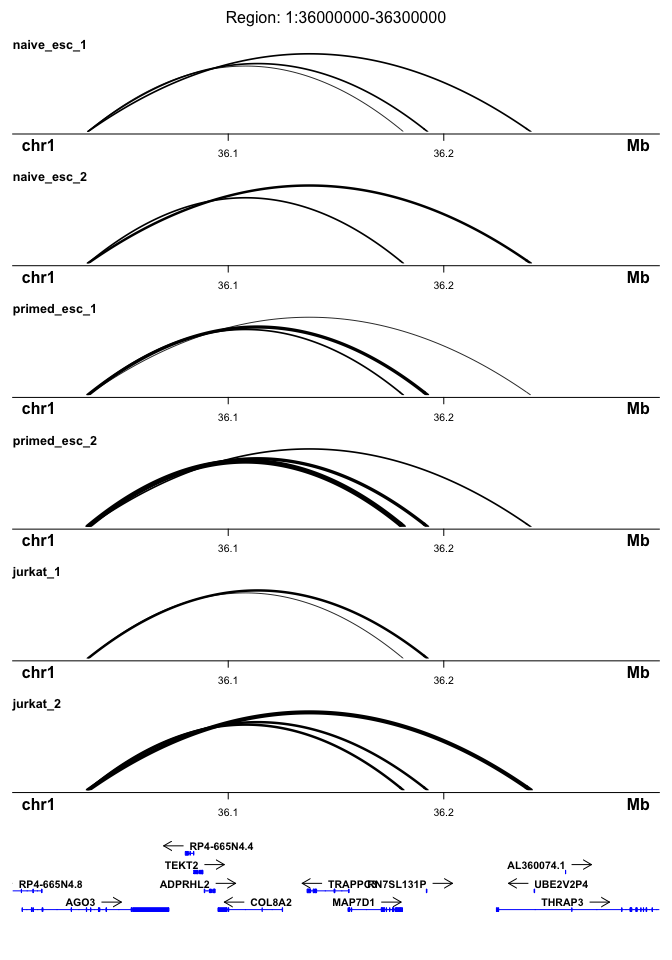

```r
regA <- GRanges(c("1"),ranges=IRanges(c(36000000),c(36300000)))
full.plot <- loopPlot(jn_res, regA)
```

When loop annotation information is available, these can be identified in the plot by indicating `colorLoops = TRUE`, which makes ctcf loops blue, enhancer-promoter loops red, and loopswith no special annotation black.

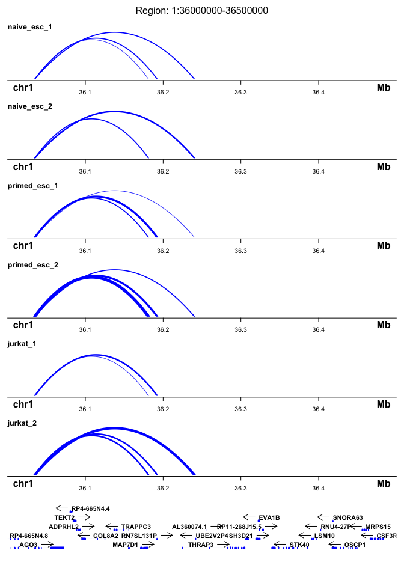

```r
regB <- GRanges(c("1"),ranges=IRanges(c(36000000),c(36500000)))
color.plot <- loopPlot(annotated_jn, regB, colorLoops = TRUE)
```

$^1$Hnisz, Denes, et al. “Activation of proto-oncogenes by disruption of chromosome neighborhoods.” Science (2016): aad9024.  
$^2$Ji, Xiong, et al. “3D Chromosome Regulatory Landscape of Human Pluripotent Cells.” Cell stem cell (2015).